# Decision Tree Classification and Evaluation

Jamison Orton

2026-06-09

# 1 Task 1: Data and Decision Tree

## 1.1 Part 1 - Set up, data import and inspection code

```r
library(C50)
library(caret)
library(rminer)
library(tictoc)
library(tidyverse)
cd <- read.csv(file = "CD_additional_balanced-1.csv", stringsAsFactors = FALSE)
```

```r
cd %>% str()
```

```
## 'data.frame':    9280 obs. of  21 variables:
##  $ age           : int  41 49 49 41 45 42 39 28 44 42 ...
##  $ job           : chr  "blue-collar" "entrepreneur" "technician" "technician" ...
##  $ marital       : chr  "divorced" "married" "married" "married" ...
##  $ education     : chr  "basic.4y" "university.degree" "basic.9y" "professional.course" ...
##  $ default       : chr  "unknown" "unknown" "no" "unknown" ...
##  $ housing       : chr  "yes" "yes" "no" "yes" ...
##  $ loan          : chr  "no" "no" "no" "no" ...
##  $ contact       : chr  "telephone" "telephone" "telephone" "telephone" ...
##  $ month         : chr  "may" "may" "may" "may" ...
##  $ day_of_week   : chr  "mon" "mon" "mon" "mon" ...
##  $ duration      : int  1575 1042 1467 579 461 673 935 1201 1030 1623 ...
##  $ campaign      : int  1 1 1 1 1 2 3 1 1 1 ...
##  $ pdays         : int  999 999 999 999 999 999 999 999 999 999 ...
##  $ previous      : int  0 0 0 0 0 0 0 0 0 0 ...
##  $ poutcome      : chr  "nonexistent" "nonexistent" "nonexistent" "nonexistent" ...
##  $ emp.var.rate  : num  1.1 1.1 1.1 1.1 1.1 1.1 1.1 1.1 1.1 1.1 ...
##  $ cons.price.idx: num  94 94 94 94 94 ...
##  $ cons.conf.idx : num  -36.4 -36.4 -36.4 -36.4 -36.4 -36.4 -36.4 -36.4 -36.4 -36.4 ...
##  $ euribor3m     : num  4.86 4.86 4.86 4.86 4.86 ...
##  $ nr.employed   : num  5191 5191 5191 5191 5191 ...
##  $ y             : chr  "yes" "yes" "yes" "yes" ...
```

```r
cd <- cd %>% mutate(across(where(is.character), as.factor))

cd %>% str()
```

```
## 'data.frame':    9280 obs. of  21 variables:
##  $ age           : int  41 49 49 41 45 42 39 28 44 42 ...
##  $ job           : Factor w/ 12 levels "admin.","blue-collar",..: 2 3 10 10 2 2 4 12 8 10 ...
##  $ marital       : Factor w/ 4 levels "divorced","married",..: 1 2 2 2 2 2 2 3 2 2 ...
##  $ education     : Factor w/ 8 levels "basic.4y","basic.6y",..: 1 7 3 6 3 3 3 8 4 6 ...
##  $ default       : Factor w/ 2 levels "no","unknown": 2 2 1 2 2 1 1 2 1 1 ...
##  $ housing       : Factor w/ 3 levels "no","unknown",..: 3 3 1 3 3 3 3 3 3 1 ...
##  $ loan          : Factor w/ 3 levels "no","unknown",..: 1 1 1 1 1 3 1 3 1 1 ...
##  $ contact       : Factor w/ 2 levels "cellular","telephone": 2 2 2 2 2 2 2 2 2 2 ...
##  $ month         : Factor w/ 10 levels "apr","aug","dec",..: 7 7 7 7 7 7 7 7 7 7 ...
##  $ day_of_week   : Factor w/ 5 levels "fri","mon","thu",..: 2 2 2 2 2 2 2 4 4 4 ...
##  $ duration      : int  1575 1042 1467 579 461 673 935 1201 1030 1623 ...
##  $ campaign      : int  1 1 1 1 1 2 3 1 1 1 ...
##  $ pdays         : int  999 999 999 999 999 999 999 999 999 999 ...
##  $ previous      : int  0 0 0 0 0 0 0 0 0 0 ...
##  $ poutcome      : Factor w/ 3 levels "failure","nonexistent",..: 2 2 2 2 2 2 2 2 2 2 ...
##  $ emp.var.rate  : num  1.1 1.1 1.1 1.1 1.1 1.1 1.1 1.1 1.1 1.1 ...
##  $ cons.price.idx: num  94 94 94 94 94 ...
##  $ cons.conf.idx : num  -36.4 -36.4 -36.4 -36.4 -36.4 -36.4 -36.4 -36.4 -36.4 -36.4 ...
##  $ euribor3m     : num  4.86 4.86 4.86 4.86 4.86 ...
##  $ nr.employed   : num  5191 5191 5191 5191 5191 ...
##  $ y             : Factor w/ 2 levels "no","yes": 2 2 2 2 2 2 2 2 2 2 ...
```

```r
cd %>% summary()
```

```
##       age                job           marital                   education
##  Min.   :17.0   admin.     :2517   divorced:1021   university.degree  :3007
##  1st Qu.:31.0   blue-collar:1769   married :5338   high.school        :2102
##  Median :38.0   technician :1459   single  :2900   professional.course:1190
##  Mean   :40.4   services   : 773   unknown :  21   basic.9y           :1177
##  3rd Qu.:48.0   management : 651                   basic.4y           : 895
##  Max.   :98.0   retired    : 595                   basic.6y           : 458
##                 (Other)    :1516                   (Other)            : 451
##     default        housing          loan           contact         month
##  no     :7824   no     :4104   no     :7688   cellular :6672   may    :2533
##  unknown:1456   unknown: 225   unknown: 225   telephone:2608   jul    :1477
##                 yes    :4951   yes    :1367                    aug    :1353
##                                                                jun    :1169
##                                                                nov    : 886
##                                                                apr    : 785
##                                                                (Other):1077
##  day_of_week    duration         campaign          pdays          previous
##  fri:1763    Min.   :   1.0   Min.   : 1.000   Min.   :  0.0   Min.   :0.0000
##  mon:1846    1st Qu.: 145.0   1st Qu.: 1.000   1st Qu.:999.0   1st Qu.:0.0000
##  thu:2000    Median : 265.0   Median : 2.000   Median :999.0   Median :0.0000
##  tue:1810    Mean   : 387.4   Mean   : 2.333   Mean   :887.3   Mean   :0.3153
##  wed:1861    3rd Qu.: 528.0   3rd Qu.: 3.000   3rd Qu.:999.0   3rd Qu.:0.0000
##              Max.   :4199.0   Max.   :39.000   Max.   :999.0   Max.   :6.0000
##
##         poutcome     emp.var.rate     cons.price.idx  cons.conf.idx
##  failure    :1074   Min.   :-3.4000   Min.   :92.20   Min.   :-50.80
##  nonexistent:7244   1st Qu.:-1.8000   1st Qu.:92.89   1st Qu.:-42.70
##  success    : 962   Median :-0.1000   Median :93.44   Median :-41.80
##                     Mean   :-0.4963   Mean   :93.48   Mean   :-40.22
##                     3rd Qu.: 1.4000   3rd Qu.:93.99   3rd Qu.:-36.40
##                     Max.   : 1.4000   Max.   :94.77   Max.   :-26.90
##
##    euribor3m      nr.employed     y
##  Min.   :0.634   Min.   :4964   no :4640
##  1st Qu.:1.244   1st Qu.:5076   yes:4640
##  Median :4.021   Median :5191
##  Mean   :2.960   Mean   :5135
##  3rd Qu.:4.959   3rd Qu.:5228
##  Max.   :5.045   Max.   :5228
##
```

## 1.2 Part 2 - Target variable

```r
cd %>% count(y) %>% mutate(percentage = round(n / sum(n) * 100, 2))
```

```
##     y    n percentage
## 1  no 4640         50
## 2 yes 4640         50
```

## 1.3 Part 3 - Data preparation

```r
set.seed(123)

train_index <- createDataPartition(cd$y, p = 0.70, list = FALSE)

train <- cd[train_index, ]
test <- cd[-train_index, ]

train %>% summary()
```

```
##       age                 job           marital                   education
##  Min.   :17.00   admin.     :1731   divorced: 727   university.degree  :2085
##  1st Qu.:31.00   blue-collar:1240   married :3732   high.school        :1457
##  Median :38.00   technician :1060   single  :2024   professional.course: 854
##  Mean   :40.52   services   : 531   unknown :  13   basic.9y           : 832
##  3rd Qu.:48.00   management : 448                   basic.4y           : 633
##  Max.   :98.00   retired    : 422                   basic.6y           : 318
##                  (Other)    :1064                   (Other)            : 317
##     default        housing          loan           contact         month
##  no     :5455   no     :2888   no     :5414   cellular :4664   may    :1762
##  unknown:1041   unknown: 152   unknown: 152   telephone:1832   jul    :1019
##                 yes    :3456   yes    : 930                    aug    : 986
##                                                                jun    : 843
##                                                                nov    : 600
##                                                                apr    : 555
##                                                                (Other): 731
##  day_of_week    duration         campaign          pdays          previous
##  fri:1210    Min.   :   1.0   Min.   : 1.000   Min.   :  0.0   Min.   :0.0000
##  mon:1294    1st Qu.: 145.0   1st Qu.: 1.000   1st Qu.:999.0   1st Qu.:0.0000
##  thu:1427    Median : 265.0   Median : 2.000   Median :999.0   Median :0.0000
##  tue:1268    Mean   : 387.3   Mean   : 2.326   Mean   :885.9   Mean   :0.3211
##  wed:1297    3rd Qu.: 529.2   3rd Qu.: 3.000   3rd Qu.:999.0   3rd Qu.:0.0000
##              Max.   :4199.0   Max.   :39.000   Max.   :999.0   Max.   :6.0000
##
##         poutcome     emp.var.rate     cons.price.idx  cons.conf.idx
##  failure    : 760   Min.   :-3.4000   Min.   :92.20   Min.   :-50.8
##  nonexistent:5056   1st Qu.:-1.8000   1st Qu.:92.89   1st Qu.:-42.7
##  success    : 680   Median :-0.1000   Median :93.44   Median :-41.8
##                     Mean   :-0.4974   Mean   :93.48   Mean   :-40.2
##                     3rd Qu.: 1.4000   3rd Qu.:93.99   3rd Qu.:-36.4
##                     Max.   : 1.4000   Max.   :94.77   Max.   :-26.9
##
##    euribor3m      nr.employed     y
##  Min.   :0.634   Min.   :4964   no :3248
##  1st Qu.:1.244   1st Qu.:5076   yes:3248
##  Median :4.021   Median :5191
##  Mean   :2.956   Mean   :5135
##  3rd Qu.:4.959   3rd Qu.:5228
##  Max.   :5.045   Max.   :5228
##
```

```r
test %>% summary()
```

```
##       age                 job          marital                   education
##  Min.   :17.00   admin.     :786   divorced: 294   university.degree  :922
##  1st Qu.:31.00   blue-collar:529   married :1606   high.school        :645
##  Median :37.00   technician :399   single  : 876   basic.9y           :345
##  Mean   :40.14   services   :242   unknown :   8   professional.course:336
##  3rd Qu.:48.00   management :203                   basic.4y           :262
##  Max.   :98.00   retired    :173                   basic.6y           :140
##                  (Other)    :452                   (Other)            :134
##     default        housing          loan           contact         month
##  no     :2369   no     :1216   no     :2274   cellular :2008   may    :771
##  unknown: 415   unknown:  73   unknown:  73   telephone: 776   jul    :458
##                 yes    :1495   yes    : 437                    aug    :367
##                                                                jun    :326
##                                                                nov    :286
##                                                                apr    :230
##                                                                (Other):346
##  day_of_week    duration         campaign         pdays          previous
##  fri:553     Min.   :   1.0   Min.   : 1.00   Min.   :  0.0   Min.   :0.0000
##  mon:552     1st Qu.: 145.0   1st Qu.: 1.00   1st Qu.:999.0   1st Qu.:0.0000
##  thu:573     Median : 266.0   Median : 2.00   Median :999.0   Median :0.0000
##  tue:542     Mean   : 387.5   Mean   : 2.35   Mean   :890.5   Mean   :0.3017
##  wed:564     3rd Qu.: 523.0   3rd Qu.: 3.00   3rd Qu.:999.0   3rd Qu.:0.0000
##              Max.   :2769.0   Max.   :30.00   Max.   :999.0   Max.   :6.0000
##
##         poutcome     emp.var.rate     cons.price.idx  cons.conf.idx
##  failure    : 314   Min.   :-3.4000   Min.   :92.20   Min.   :-50.80
##  nonexistent:2188   1st Qu.:-1.8000   1st Qu.:92.89   1st Qu.:-42.70
##  success    : 282   Median :-0.1000   Median :93.44   Median :-41.80
##                     Mean   :-0.4937   Mean   :93.48   Mean   :-40.25
##                     3rd Qu.: 1.4000   3rd Qu.:93.99   3rd Qu.:-36.40
##                     Max.   : 1.4000   Max.   :94.77   Max.   :-26.90
##
##    euribor3m      nr.employed     y
##  Min.   :0.635   Min.   :4964   no :1392
##  1st Qu.:1.250   1st Qu.:5076   yes:1392
##  Median :4.021   Median :5191
##  Mean   :2.971   Mean   :5135
##  3rd Qu.:4.958   3rd Qu.:5228
##  Max.   :5.045   Max.   :5228
##
```

```r
train %>%
  count(y) %>%
  mutate(percent = round(n / sum(n) * 100, 2))
```

```
##     y    n percent
## 1  no 3248      50
## 2 yes 3248      50
```

```r
test %>%
  count(y) %>%
  mutate(percent = round(n / sum(n) * 100, 2))
```

```
##     y    n percent
## 1  no 1392      50
## 2 yes 1392      50
```

## 1.4 Part 4 - Train Decision Trees to classify y

```r
train_c50_model <- function(cf_value) {
  C5.0(
    y ~ .,
    data = train,
    control = C5.0Control(
      CF = cf_value,
      earlyStopping = FALSE,
      noGlobalPruning = FALSE
    )
  )
}

model_cf_97 <- train_c50_model(0.97)
model_cf_35 <- train_c50_model(0.35)
model_cf_12 <- train_c50_model(0.12)
model_cf_08 <- train_c50_model(0.08)
model_cf_05 <- train_c50_model(0.05)
model_cf_025 <- train_c50_model(0.025)
model_cf_001 <- train_c50_model(0.001)
```

## 1.5 Part 5 - Model Information

### 1.5.1 Part A

```r
tree_sizes <- data.frame(
  model = c(
    "model_cf_97",
    "model_cf_35",
    "model_cf_12",
    "model_cf_08",
    "model_cf_05",
    "model_cf_025",
    "model_cf_001"
  ),

  CF = c(0.97, 0.35, 0.12, 0.08, 0.05, 0.025, 0.001),

  tree_size = c(
    model_cf_97$size,
    model_cf_35$size,
    model_cf_12$size,
    model_cf_08$size,
    model_cf_05$size,
    model_cf_025$size,
    model_cf_001$size
  )
)

tree_sizes
```

```
##          model    CF tree_size
## 1  model_cf_97 0.970       339
## 2  model_cf_35 0.350       100
## 3  model_cf_12 0.120        59
## 4  model_cf_08 0.080        29
## 5  model_cf_05 0.050        29
## 6 model_cf_025 0.025        26
## 7 model_cf_001 0.001        13
```

### 1.5.2 Part B

Tree complexity is based on tree size. Tree size represents the number of terminal decision rules in the model. A tree with more leaf nodes is more complex reuiring more specific rules for classifying observations. A tree with fewer leaf nodes is less complex and uses fewer rules and is easier to interpret.

### 1.5.3 Part C

```r
least_complex_model_name <- tree_sizes %>%
  arrange(tree_size) %>%
  slice(1) %>%
  pull(model)
least_complex_model <- get(least_complex_model_name)

least_complex_model_name
```

```
## [1] "model_cf_001"
```

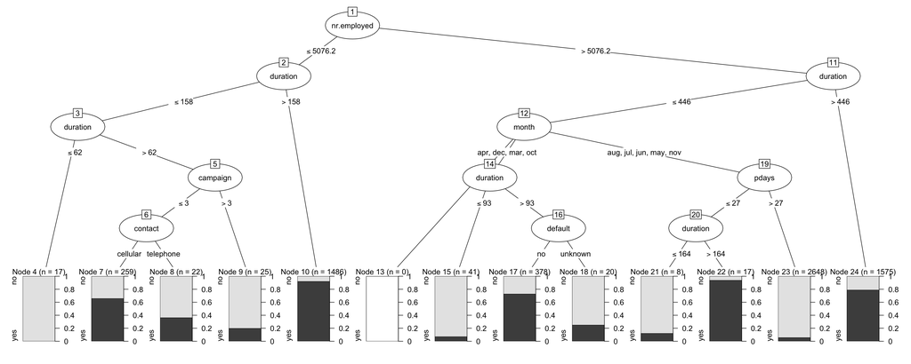

```r
plot(least_complex_model)
```

### Part D

```r
least_complex_model
```

```
##
## Call:
## C5.0.formula(formula = y ~ ., data = train, control = C5.0Control(CF
##  = cf_value, earlyStopping = FALSE, noGlobalPruning = FALSE))
##
## Classification Tree
## Number of samples: 6496
## Number of predictors: 20
##
## Tree size: 13
##
## Non-standard options: attempt to group attributes, confidence level: 0.001
```

For the instance with nr.employed = 6000 and duration = 500, I used the least complex decision tree to follow the model’s decision rules. The least complex tree begins by checking the value of nr.employed if it is <= 5076.2 then it will go to duration. In the instance of nr.employed = 6000 and duration = 500 the model predicts yes as it is yes 80% of the time.

## 1.6 Part 6 - Predict on the Train and Test sets with each trained model

```r
# Predictions on the Train set
pred_train_cf_97 <- predict(model_cf_97, newdata = train)
pred_train_cf_35 <- predict(model_cf_35, newdata = train)
pred_train_cf_12 <- predict(model_cf_12, newdata = train)
pred_train_cf_08 <- predict(model_cf_08, newdata = train)
pred_train_cf_05 <- predict(model_cf_05, newdata = train)
pred_train_cf_025 <- predict(model_cf_025, newdata = train)
pred_train_cf_001 <- predict(model_cf_001, newdata = train)

# Predictions on the Test set
pred_test_cf_97 <- predict(model_cf_97, newdata = test)
pred_test_cf_35 <- predict(model_cf_35, newdata = test)
pred_test_cf_12 <- predict(model_cf_12, newdata = test)
pred_test_cf_08 <- predict(model_cf_08, newdata = test)
pred_test_cf_05 <- predict(model_cf_05, newdata = test)
pred_test_cf_025 <- predict(model_cf_025, newdata = test)
pred_test_cf_001 <- predict(model_cf_001, newdata = test)
```

## 1.7 Part 7 - Generate Confusion Matrices for each trained Model for both Train and Test

```r
# Confusion matrices for the Train set
cm_train_cf_97 <- confusionMatrix(pred_train_cf_97, train$y)
cm_train_cf_35 <- confusionMatrix(pred_train_cf_35, train$y)
cm_train_cf_12 <- confusionMatrix(pred_train_cf_12, train$y)
cm_train_cf_08 <- confusionMatrix(pred_train_cf_08, train$y)
cm_train_cf_05 <- confusionMatrix(pred_train_cf_05, train$y)
cm_train_cf_025 <- confusionMatrix(pred_train_cf_025, train$y)
cm_train_cf_001 <- confusionMatrix(pred_train_cf_001, train$y)

# Confusion matrices for the Test set
cm_test_cf_97 <- confusionMatrix(pred_test_cf_97, test$y)
cm_test_cf_35 <- confusionMatrix(pred_test_cf_35, test$y)
cm_test_cf_12 <- confusionMatrix(pred_test_cf_12, test$y)
cm_test_cf_08 <- confusionMatrix(pred_test_cf_08, test$y)
cm_test_cf_05 <- confusionMatrix(pred_test_cf_05, test$y)
cm_test_cf_025 <- confusionMatrix(pred_test_cf_025, test$y)
cm_test_cf_001 <- confusionMatrix(pred_test_cf_001, test$y)
```

```r
cm_train_cf_97
```

```
## Confusion Matrix and Statistics
##
##           Reference
## Prediction   no  yes
##        no  2998  115
##        yes  250 3133
##
##                Accuracy : 0.9438
##                  95% CI : (0.9379, 0.9493)
##     No Information Rate : 0.5
##     P-Value [Acc > NIR] : < 2.2e-16
##
##                   Kappa : 0.8876
##
##  Mcnemar's Test P-Value : 2.318e-12
##
##             Sensitivity : 0.9230
##             Specificity : 0.9646
##          Pos Pred Value : 0.9631
##          Neg Pred Value : 0.9261
##              Prevalence : 0.5000
##          Detection Rate : 0.4615
##    Detection Prevalence : 0.4792
##       Balanced Accuracy : 0.9438
##
##        'Positive' Class : no
##
```

```r
cm_train_cf_35
```

```
## Confusion Matrix and Statistics
##
##           Reference
## Prediction   no  yes
##        no  2810  133
##        yes  438 3115
##
##                Accuracy : 0.9121
##                  95% CI : (0.905, 0.9189)
##     No Information Rate : 0.5
##     P-Value [Acc > NIR] : < 2.2e-16
##
##                   Kappa : 0.8242
##
##  Mcnemar's Test P-Value : < 2.2e-16
##
##             Sensitivity : 0.8651
##             Specificity : 0.9591
##          Pos Pred Value : 0.9548
##          Neg Pred Value : 0.8767
##              Prevalence : 0.5000
##          Detection Rate : 0.4326
##    Detection Prevalence : 0.4530
##       Balanced Accuracy : 0.9121
##
##        'Positive' Class : no
##
```

```r
cm_train_cf_12
```

```
## Confusion Matrix and Statistics
##
##           Reference
## Prediction   no  yes
##        no  2746  130
##        yes  502 3118
##
##                Accuracy : 0.9027
##                  95% CI : (0.8952, 0.9098)
##     No Information Rate : 0.5
##     P-Value [Acc > NIR] : < 2.2e-16
##
##                   Kappa : 0.8054
##
##  Mcnemar's Test P-Value : < 2.2e-16
##
##             Sensitivity : 0.8454
##             Specificity : 0.9600
##          Pos Pred Value : 0.9548
##          Neg Pred Value : 0.8613
##              Prevalence : 0.5000
##          Detection Rate : 0.4227
##    Detection Prevalence : 0.4427
##       Balanced Accuracy : 0.9027
##
##        'Positive' Class : no
##
```

```r
cm_train_cf_08
```

```
## Confusion Matrix and Statistics
##
##           Reference
## Prediction   no  yes
##        no  2680  139
##        yes  568 3109
##
##                Accuracy : 0.8912
##                  95% CI : (0.8833, 0.8986)
##     No Information Rate : 0.5
##     P-Value [Acc > NIR] : < 2.2e-16
##
##                   Kappa : 0.7823
##
##  Mcnemar's Test P-Value : < 2.2e-16
##
##             Sensitivity : 0.8251
##             Specificity : 0.9572
##          Pos Pred Value : 0.9507
##          Neg Pred Value : 0.8455
##              Prevalence : 0.5000
##          Detection Rate : 0.4126
##    Detection Prevalence : 0.4340
##       Balanced Accuracy : 0.8912
##
##        'Positive' Class : no
##
```

```r
cm_train_cf_05
```

```
## Confusion Matrix and Statistics
##
##           Reference
## Prediction   no  yes
##        no  2680  139
##        yes  568 3109
##
##                Accuracy : 0.8912
##                  95% CI : (0.8833, 0.8986)
##     No Information Rate : 0.5
##     P-Value [Acc > NIR] : < 2.2e-16
##
##                   Kappa : 0.7823
##
##  Mcnemar's Test P-Value : < 2.2e-16
##
##             Sensitivity : 0.8251
##             Specificity : 0.9572
##          Pos Pred Value : 0.9507
##          Neg Pred Value : 0.8455
##              Prevalence : 0.5000
##          Detection Rate : 0.4126
##    Detection Prevalence : 0.4340
##       Balanced Accuracy : 0.8912
##
##        'Positive' Class : no
##
```

```r
cm_train_cf_025
```

```
## Confusion Matrix and Statistics
##
##           Reference
## Prediction   no  yes
##        no  2698  171
##        yes  550 3077
##
##                Accuracy : 0.889
##                  95% CI : (0.8811, 0.8965)
##     No Information Rate : 0.5
##     P-Value [Acc > NIR] : < 2.2e-16
##
##                   Kappa : 0.778
##
##  Mcnemar's Test P-Value : < 2.2e-16
##
##             Sensitivity : 0.8307
##             Specificity : 0.9474
##          Pos Pred Value : 0.9404
##          Neg Pred Value : 0.8484
##              Prevalence : 0.5000
##          Detection Rate : 0.4153
##    Detection Prevalence : 0.4417
##       Balanced Accuracy : 0.8890
##
##        'Positive' Class : no
##
```

```r
cm_train_cf_001
```

```
## Confusion Matrix and Statistics
##
##           Reference
## Prediction   no  yes
##        no  2609  172
##        yes  639 3076
##
##                Accuracy : 0.8752
##                  95% CI : (0.8669, 0.8831)
##     No Information Rate : 0.5
##     P-Value [Acc > NIR] : < 2.2e-16
##
##                   Kappa : 0.7503
##
##  Mcnemar's Test P-Value : < 2.2e-16
##
##             Sensitivity : 0.8033
##             Specificity : 0.9470
##          Pos Pred Value : 0.9382
##          Neg Pred Value : 0.8280
##              Prevalence : 0.5000
##          Detection Rate : 0.4016
##    Detection Prevalence : 0.4281
##       Balanced Accuracy : 0.8752
##
##        'Positive' Class : no
##
```

```r
cm_test_cf_97
```

```
## Confusion Matrix and Statistics
##
##           Reference
## Prediction   no  yes
##        no  1186  168
##        yes  206 1224
##
##                Accuracy : 0.8657
##                  95% CI : (0.8524, 0.8781)
##     No Information Rate : 0.5
##     P-Value [Acc > NIR] : < 2e-16
##
##                   Kappa : 0.7313
##
##  Mcnemar's Test P-Value : 0.05572
##
##             Sensitivity : 0.8520
##             Specificity : 0.8793
##          Pos Pred Value : 0.8759
##          Neg Pred Value : 0.8559
##              Prevalence : 0.5000
##          Detection Rate : 0.4260
##    Detection Prevalence : 0.4864
##       Balanced Accuracy : 0.8657
##
##        'Positive' Class : no
##
```

```r
cm_test_cf_35
```

```
## Confusion Matrix and Statistics
##
##           Reference
## Prediction   no  yes
##        no  1181  112
##        yes  211 1280
##
##                Accuracy : 0.884
##                  95% CI : (0.8715, 0.8956)
##     No Information Rate : 0.5
##     P-Value [Acc > NIR] : < 2.2e-16
##
##                   Kappa : 0.768
##
##  Mcnemar's Test P-Value : 4.956e-08
##
##             Sensitivity : 0.8484
##             Specificity : 0.9195
##          Pos Pred Value : 0.9134
##          Neg Pred Value : 0.8585
##              Prevalence : 0.5000
##          Detection Rate : 0.4242
##    Detection Prevalence : 0.4644
##       Balanced Accuracy : 0.8840
##
##        'Positive' Class : no
##
```

```r
cm_test_cf_12
```

```
## Confusion Matrix and Statistics
##
##           Reference
## Prediction   no  yes
##        no  1166   94
##        yes  226 1298
##
##                Accuracy : 0.8851
##                  95% CI : (0.8726, 0.8967)
##     No Information Rate : 0.5
##     P-Value [Acc > NIR] : < 2.2e-16
##
##                   Kappa : 0.7701
##
##  Mcnemar's Test P-Value : 2.423e-13
##
##             Sensitivity : 0.8376
##             Specificity : 0.9325
##          Pos Pred Value : 0.9254
##          Neg Pred Value : 0.8517
##              Prevalence : 0.5000
##          Detection Rate : 0.4188
##    Detection Prevalence : 0.4526
##       Balanced Accuracy : 0.8851
##
##        'Positive' Class : no
##
```

```r
cm_test_cf_08
```

```
## Confusion Matrix and Statistics
##
##           Reference
## Prediction   no  yes
##        no  1159   90
##        yes  233 1302
##
##                Accuracy : 0.884
##                  95% CI : (0.8715, 0.8956)
##     No Information Rate : 0.5
##     P-Value [Acc > NIR] : < 2.2e-16
##
##                   Kappa : 0.768
##
##  Mcnemar's Test P-Value : 2.765e-15
##
##             Sensitivity : 0.8326
##             Specificity : 0.9353
##          Pos Pred Value : 0.9279
##          Neg Pred Value : 0.8482
##              Prevalence : 0.5000
##          Detection Rate : 0.4163
##    Detection Prevalence : 0.4486
##       Balanced Accuracy : 0.8840
##
##        'Positive' Class : no
##
```

```r
cm_test_cf_05
```

```
## Confusion Matrix and Statistics
##
##           Reference
## Prediction   no  yes
##        no  1159   90
##        yes  233 1302
##
##                Accuracy : 0.884
##                  95% CI : (0.8715, 0.8956)
##     No Information Rate : 0.5
##     P-Value [Acc > NIR] : < 2.2e-16
##
##                   Kappa : 0.768
##
##  Mcnemar's Test P-Value : 2.765e-15
##
##             Sensitivity : 0.8326
##             Specificity : 0.9353
##          Pos Pred Value : 0.9279
##          Neg Pred Value : 0.8482
##              Prevalence : 0.5000
##          Detection Rate : 0.4163
##    Detection Prevalence : 0.4486
##       Balanced Accuracy : 0.8840
##
##        'Positive' Class : no
##
```

```r
cm_test_cf_025
```

```
## Confusion Matrix and Statistics
##
##           Reference
## Prediction   no  yes
##        no  1165  101
##        yes  227 1291
##
##                Accuracy : 0.8822
##                  95% CI : (0.8696, 0.8939)
##     No Information Rate : 0.5
##     P-Value [Acc > NIR] : < 2.2e-16
##
##                   Kappa : 0.7644
##
##  Mcnemar's Test P-Value : 5.129e-12
##
##             Sensitivity : 0.8369
##             Specificity : 0.9274
##          Pos Pred Value : 0.9202
##          Neg Pred Value : 0.8505
##              Prevalence : 0.5000
##          Detection Rate : 0.4185
##    Detection Prevalence : 0.4547
##       Balanced Accuracy : 0.8822
##
##        'Positive' Class : no
##
```

```r
cm_test_cf_001
```

```
## Confusion Matrix and Statistics
##
##           Reference
## Prediction   no  yes
##        no  1134   83
##        yes  258 1309
##
##                Accuracy : 0.8775
##                  95% CI : (0.8648, 0.8895)
##     No Information Rate : 0.5
##     P-Value [Acc > NIR] : < 2.2e-16
##
##                   Kappa : 0.755
##
##  Mcnemar's Test P-Value : < 2.2e-16
##
##             Sensitivity : 0.8147
##             Specificity : 0.9404
##          Pos Pred Value : 0.9318
##          Neg Pred Value : 0.8354
##              Prevalence : 0.5000
##          Detection Rate : 0.4073
##    Detection Prevalence : 0.4371
##       Balanced Accuracy : 0.8775
##
##        'Positive' Class : no
##
```

## 1.8 Part 8 - Generate Evaluation Metrics for each Model

```r
# Metrics requested: F1, Accuracy, Precision, and Recall/TPR
metric_list <- c("F1", "ACC", "PRECISION", "TPR")

# Train set metrics
metrics_train_cf_97 <- mmetric(train$y, pred_train_cf_97, metric = metric_list)
metrics_train_cf_35 <- mmetric(train$y, pred_train_cf_35, metric = metric_list)
metrics_train_cf_12 <- mmetric(train$y, pred_train_cf_12, metric = metric_list)
metrics_train_cf_08 <- mmetric(train$y, pred_train_cf_08, metric = metric_list)
metrics_train_cf_05 <- mmetric(train$y, pred_train_cf_05, metric = metric_list)
metrics_train_cf_025 <- mmetric(train$y, pred_train_cf_025, metric = metric_list)
metrics_train_cf_001 <- mmetric(train$y, pred_train_cf_001, metric = metric_list)

# Test set metrics
metrics_test_cf_97 <- mmetric(test$y, pred_test_cf_97, metric = metric_list)
metrics_test_cf_35 <- mmetric(test$y, pred_test_cf_35, metric = metric_list)
metrics_test_cf_12 <- mmetric(test$y, pred_test_cf_12, metric = metric_list)
metrics_test_cf_08 <- mmetric(test$y, pred_test_cf_08, metric = metric_list)
metrics_test_cf_05 <- mmetric(test$y, pred_test_cf_05, metric = metric_list)
metrics_test_cf_025 <- mmetric(test$y, pred_test_cf_025, metric = metric_list)
metrics_test_cf_001 <- mmetric(test$y, pred_test_cf_001, metric = metric_list)
```

```r
evaluation_results <- data.frame(
  dataset = c(
    rep("Train", 7),
    rep("Test", 7)
  ),

  model = rep(
    c(
      "model_cf_97",
      "model_cf_35",
      "model_cf_12",
      "model_cf_08",
      "model_cf_05",
      "model_cf_025",
      "model_cf_001"
    ),
    2
  ),

  CF = rep(
    c(0.97, 0.35, 0.12, 0.08, 0.05, 0.025, 0.001),
    2
  ),

  F1 = c(
    metrics_train_cf_97["F1"],
    metrics_train_cf_35["F1"],
    metrics_train_cf_12["F1"],
    metrics_train_cf_08["F1"],
    metrics_train_cf_05["F1"],
    metrics_train_cf_025["F1"],
    metrics_train_cf_001["F1"],
    metrics_test_cf_97["F1"],
    metrics_test_cf_35["F1"],
    metrics_test_cf_12["F1"],
    metrics_test_cf_08["F1"],
    metrics_test_cf_05["F1"],
    metrics_test_cf_025["F1"],
    metrics_test_cf_001["F1"]
  ),

  Accuracy = c(
    metrics_train_cf_97["ACC"],
    metrics_train_cf_35["ACC"],
    metrics_train_cf_12["ACC"],
    metrics_train_cf_08["ACC"],
    metrics_train_cf_05["ACC"],
    metrics_train_cf_025["ACC"],
    metrics_train_cf_001["ACC"],
    metrics_test_cf_97["ACC"],
    metrics_test_cf_35["ACC"],
    metrics_test_cf_12["ACC"],
    metrics_test_cf_08["ACC"],
    metrics_test_cf_05["ACC"],
    metrics_test_cf_025["ACC"],
    metrics_test_cf_001["ACC"]
  ),

  Precision = c(
    metrics_train_cf_97["PRECISION"],
    metrics_train_cf_35["PRECISION"],
    metrics_train_cf_12["PRECISION"],
    metrics_train_cf_08["PRECISION"],
    metrics_train_cf_05["PRECISION"],
    metrics_train_cf_025["PRECISION"],
    metrics_train_cf_001["PRECISION"],
    metrics_test_cf_97["PRECISION"],
    metrics_test_cf_35["PRECISION"],
    metrics_test_cf_12["PRECISION"],
    metrics_test_cf_08["PRECISION"],
    metrics_test_cf_05["PRECISION"],
    metrics_test_cf_025["PRECISION"],
    metrics_test_cf_001["PRECISION"]
  ),

  Recall = c(
    metrics_train_cf_97["TPR"],
    metrics_train_cf_35["TPR"],
    metrics_train_cf_12["TPR"],
    metrics_train_cf_08["TPR"],
    metrics_train_cf_05["TPR"],
    metrics_train_cf_025["TPR"],
    metrics_train_cf_001["TPR"],
    metrics_test_cf_97["TPR"],
    metrics_test_cf_35["TPR"],
    metrics_test_cf_12["TPR"],
    metrics_test_cf_08["TPR"],
    metrics_test_cf_05["TPR"],
    metrics_test_cf_025["TPR"],
    metrics_test_cf_001["TPR"]
  )
)

evaluation_results
```

```
##    dataset        model    CF F1 Accuracy Precision Recall
## 1    Train  model_cf_97 0.970 NA 94.38116        NA     NA
## 2    Train  model_cf_35 0.350 NA 91.20998        NA     NA
## 3    Train  model_cf_12 0.120 NA 90.27094        NA     NA
## 4    Train  model_cf_08 0.080 NA 89.11638        NA     NA
## 5    Train  model_cf_05 0.050 NA 89.11638        NA     NA
## 6    Train model_cf_025 0.025 NA 88.90086        NA     NA
## 7    Train model_cf_001 0.001 NA 87.51539        NA     NA
## 8     Test  model_cf_97 0.970 NA 86.56609        NA     NA
## 9     Test  model_cf_35 0.350 NA 88.39799        NA     NA
## 10    Test  model_cf_12 0.120 NA 88.50575        NA     NA
## 11    Test  model_cf_08 0.080 NA 88.39799        NA     NA
## 12    Test  model_cf_05 0.050 NA 88.39799        NA     NA
## 13    Test model_cf_025 0.025 NA 88.21839        NA     NA
## 14    Test model_cf_001 0.001 NA 87.75144        NA     NA
```

## 1.9 Part 9 - Show the feature importance for each Model

```r
# Feature importance for each trained C5.0 decision tree
importance_cf_97 <- C5imp(model_cf_97)
importance_cf_35 <- C5imp(model_cf_35)
importance_cf_12 <- C5imp(model_cf_12)
importance_cf_08 <- C5imp(model_cf_08)
importance_cf_05 <- C5imp(model_cf_05)
importance_cf_025 <- C5imp(model_cf_025)
importance_cf_001 <- C5imp(model_cf_001)
importance_cf_97
```

```
##                Overall
## duration        100.00
## nr.employed     100.00
## month            76.88
## euribor3m        47.52
## pdays            45.14
## poutcome         26.54
## job              26.31
## day_of_week      20.35
## cons.price.idx   19.06
## contact          17.29
## default          11.10
## education         8.97
## campaign          8.67
## cons.conf.idx     7.97
## emp.var.rate      7.16
## loan              6.62
## marital           5.85
## housing           4.91
## age               3.66
## previous          3.22
```

```r
importance_cf_35
```

```
##                Overall
## duration        100.00
## nr.employed     100.00
## month            49.85
## pdays            45.14
## euribor3m        44.57
## cons.price.idx   12.47
## cons.conf.idx     7.97
## day_of_week       7.07
## default           6.43
## emp.var.rate      5.82
## job               5.34
## campaign          5.26
## contact           4.33
## poutcome          3.66
## previous          2.71
## age               1.14
## marital           1.11
## education         1.09
## loan              0.65
## housing           0.62
```

```r
importance_cf_12
```

```
##                Overall
## duration        100.00
## nr.employed     100.00
## month            49.78
## pdays            45.14
## euribor3m        41.30
## cons.price.idx   24.25
## cons.conf.idx     7.97
## day_of_week       7.37
## default           6.43
## emp.var.rate      5.82
## campaign          5.08
## contact           4.33
## poutcome          3.66
## previous          2.71
## age               1.48
## loan              0.60
## education         0.35
## job               0.00
## marital           0.00
## housing           0.00
```

```r
importance_cf_08
```

```
##                Overall
## duration        100.00
## nr.employed     100.00
## month            47.91
## pdays            41.15
## euribor3m        40.76
## cons.price.idx   24.25
## day_of_week       7.37
## default           6.13
## emp.var.rate      5.82
## cons.conf.idx     5.53
## campaign          5.08
## contact           4.33
## age               0.00
## job               0.00
## marital           0.00
## education         0.00
## housing           0.00
## loan              0.00
## previous          0.00
## poutcome          0.00
```

```r
importance_cf_05
```

```
##                Overall
## duration        100.00
## nr.employed     100.00
## month            47.91
## pdays            41.15
## euribor3m        40.76
## cons.price.idx   24.25
## day_of_week       7.37
## default           6.13
## emp.var.rate      5.82
## cons.conf.idx     5.53
## campaign          5.08
## contact           4.33
## age               0.00
## job               0.00
## marital           0.00
## education         0.00
## housing           0.00
## loan              0.00
## previous          0.00
## poutcome          0.00
```

```r
importance_cf_025
```

```
##                Overall
## duration        100.00
## nr.employed     100.00
## month            47.91
## pdays            41.15
## euribor3m        40.76
## cons.price.idx   24.25
## default           6.13
## emp.var.rate      5.82
## day_of_week       5.68
## cons.conf.idx     5.53
## campaign          5.08
## contact           4.33
## age               0.00
## job               0.00
## marital           0.00
## education         0.00
## housing           0.00
## loan              0.00
## previous          0.00
## poutcome          0.00
```

```r
importance_cf_001
```

```
##                Overall
## duration        100.00
## nr.employed     100.00
## month            47.91
## pdays            41.15
## default           6.13
## campaign          4.71
## contact           4.33
## age               0.00
## job               0.00
## marital           0.00
## education         0.00
## housing           0.00
## loan              0.00
## day_of_week       0.00
## previous          0.00
## poutcome          0.00
## emp.var.rate      0.00
## cons.price.idx    0.00
## cons.conf.idx     0.00
## euribor3m         0.00
```

# 2 Task 2: Reflections

Changing the CF hyperparameter affected the complexity of the decision tree models. In general, higher CF values allowed for more splits, creating larger and more complex trees. Lower CF values increased pruning creating smaller trees. In my results, the most complex model was the model with a CF of .97 creating 339 leaf nodes. The least complex was the model with a CF of .001 creating 13 leaf nodes. I defined complexity using the number of leaf nodes because each leaf node represents a final decision rule. Higher leaf nodes are harder to interpret, while a model with fewer nodes is easier to explain.

The best performing model on the training set was the model with CF of .97. This model had 339 leaf nodes and achieved a training accuracy of 94.38%. The best-performing model on the testing set was the model with CF of .12. The model had 59 leaf nodes and achieved a test accuracy of 88.5%.

Overall the relationship between complexity and performance showed that more complex trees tended to perform better on the training data but they did not always perform better on the testing data. This suggest that some of the larger trees may have overfit the training data.

If I were presenting these results in a meeting, I would choose the model with CF of .05. While it does not have the highest training accuracy, it performs well on the testing set and has a manageable number of leaf nodes. This makes it easier to explain how the model makes predections.